# Linear Model Selection, Regularization and Moving Beyond Linearity

Module 09

Ray J. Hoobler

## Libraries

```r
library(tidyverse)
library(broom) # For tidying model output
library(leaps) # For best subset selection
library(readxl) # For reading Excel files
library(patchwork) # For combining plots
library(latex2exp) # For LaTeX expressions
library(rlang) # For working with formulas
library(glmnet) # For ridge regression and the lasso
```

# Linear Model Selection and Regularization

## Subset Selection (1/3)

### Best Subset Selection

### Stepwise Selection

### Choosing the Optimal Model

## Subset Selection (2/3)

For a linear model with $p$ predictors

$$Y = \beta_0 + \beta_1X_1 + \beta_2X_2 + \ldots + \beta_pX_p + \epsilon$$

there are $2^p$ possible models.

For example with $p=3$ predictors, there are $2^3 = 8$ possible models. They can be expressed as:

$$\begin{align*}
Y &= \beta_0 + \beta_1X_1 + \beta_2X_2 + \beta_3X_3 + \epsilon \\
Y &= \beta_0 + \beta_1X_1 + \beta_2X_2 + \epsilon \\
Y &= \beta_0 + \beta_1X_1 + \beta_3X_3 + \epsilon \\
Y &= \beta_0 + \beta_2X_2 + \beta_3X_3 + \epsilon \\
Y &= \beta_0 + \beta_1X_1 + \epsilon \\
Y &= \beta_0 + \beta_2X_2 + \epsilon \\
Y &= \beta_0 + \beta_3X_3 + \epsilon \\
Y &= \beta_0 + \epsilon \\
\end{align*}$$

## Subset Selection (3/3)

### What are we trying to achieve?

**Prediction Accuracy**

Constraints on the number of predictors can lead to better prediction accuracy.

**Model Interpretability**

A model with fewer predictors is easier to interpret.

## Best Subset Selection (1/9)

### ISLR Algorithm 6.1

1. Let $M_0$ denote the null model, which contains no predictors.
2. For $k=1,2,\ldots,p$:
   1. Fit all $\binom{p}{k}$ models that contain exactly $k$ predictors.
   2. Pick the best among these models, and call it $M_k$. Here best is defined as having the smallest RSS or highest $R^2$.
3. Select a single best model from among $M_0, M_1, \ldots, M_p$ using cross-validated prediction error, $C_p$, BIC, or adjusted $R^2$.

**Note:**

Step 2 is preformed on a training set.  
Step 3 is performed on a validation set.

$$\binom{p}{k} = (\textrm{p choose k})= \frac{p!}{k!(p-k)!}$$

## Best Subset Selection (2/9)

### Load the concrete data set

Variable Information:

Given is the variable name, variable type, the measurement unit and a brief description. The concrete compressive strength is the regression problem. The order of this listing corresponds to the order of numerals along the rows of the database.

Name – Data Type – Measurement – Description

- Cement (component 1) – quantitative – kg in a m3 mixture – Input Variable
- Blast Furnace Slag (component 2) – quantitative – kg in a m3 mixture – Input Variable
- Fly Ash (component 3) – quantitative – kg in a m3 mixture – Input Variable
- Water (component 4) – quantitative – kg in a m3 mixture – Input Variable
- Superplasticizer (component 5) – quantitative – kg in a m3 mixture – Input Variable
- Coarse Aggregate (component 6) – quantitative – kg in a m3 mixture – Input Variable
- Fine Aggregate (component 7) – quantitative – kg in a m3 mixture – Input Variable
- Age – quantitative – Day (1~365) – Input Variable
- Concrete compressive strength – quantitative – MPa – Output Variable

```r
concrete_column_names <- c("cement", "slag", "ash", "water", "superplasticizer", "coarse_aggregate", "fine_aggregate", "age", "strength")

concrete <- read_xls("datasets/concrete+compressive+strength/Concrete_Data.xls") |>
  rename_with(~ concrete_column_names)

concrete
```

| cement | slag | ash | water | superplasticizer | coarse_aggregate | fine_aggregate | age | strength |
| --- | --- | --- | --- | --- | --- | --- | --- | --- |
| 540.00 | 0.00 | 0.00 | 162.00 | 2.500 | 1040.00 | 676.00 | 28 | 79.986111 |
| 540.00 | 0.00 | 0.00 | 162.00 | 2.500 | 1055.00 | 676.00 | 28 | 61.887366 |
| 332.50 | 142.50 | 0.00 | 228.00 | 0.000 | 932.00 | 594.00 | 270 | 40.269535 |
| 332.50 | 142.50 | 0.00 | 228.00 | 0.000 | 932.00 | 594.00 | 365 | 41.052780 |
| 198.60 | 132.40 | 0.00 | 192.00 | 0.000 | 978.40 | 825.50 | 360 | 44.296075 |
| 266.00 | 114.00 | 0.00 | 228.00 | 0.000 | 932.00 | 670.00 | 90 | 47.029847 |
| 380.00 | 95.00 | 0.00 | 228.00 | 0.000 | 932.00 | 594.00 | 365 | 43.698299 |
| 380.00 | 95.00 | 0.00 | 228.00 | 0.000 | 932.00 | 594.00 | 28 | 36.447770 |
| 266.00 | 114.00 | 0.00 | 228.00 | 0.000 | 932.00 | 670.00 | 28 | 45.854291 |
| 475.00 | 0.00 | 0.00 | 228.00 | 0.000 | 932.00 | 594.00 | 28 | 39.289790 |

[output cut: 1020 more lines]

## Best Subset Selection (3/9)

```r
regfit_full_8 <- regsubsets(strength ~ ., data = concrete, nvmax = 8)

summary(regfit_full_8)
```

```
Subset selection object
Call: regsubsets.formula(strength ~ ., data = concrete, nvmax = 8)
8 Variables  (and intercept)
                 Forced in Forced out
cement               FALSE      FALSE
slag                 FALSE      FALSE
ash                  FALSE      FALSE
water                FALSE      FALSE
superplasticizer     FALSE      FALSE
coarse_aggregate     FALSE      FALSE
fine_aggregate       FALSE      FALSE
age                  FALSE      FALSE
1 subsets of each size up to 8
Selection Algorithm: exhaustive
         cement slag ash water superplasticizer coarse_aggregate fine_aggregate
1  ( 1 ) "*"    " "  " " " "   " "              " "              " "
2  ( 1 ) "*"    " "  " " " "   "*"              " "              " "
3  ( 1 ) "*"    " "  " " " "   "*"              " "              " "
4  ( 1 ) "*"    "*"  " " "*"   " "              " "              " "
5  ( 1 ) "*"    "*"  "*" "*"   " "              " "              " "
6  ( 1 ) "*"    "*"  "*" "*"   "*"              " "              " "
7  ( 1 ) "*"    "*"  "*" "*"   "*"              "*"              " "
8  ( 1 ) "*"    "*"  "*" "*"   "*"              "*"              "*"
         age
1  ( 1 ) " "
2  ( 1 ) " "
3  ( 1 ) "*"
4  ( 1 ) "*"
5  ( 1 ) "*"
6  ( 1 ) "*"
7  ( 1 ) "*"
8  ( 1 ) "*"
```

## Best Subset Selection (4/9)

```r
regfit_full <- regsubsets(strength ~ ., data = concrete, nvmax = 8, nbest = 256, really.big = TRUE)

summary(regfit_full)
```

```
Subset selection object
Call: regsubsets.formula(strength ~ ., data = concrete, nvmax = 8,
    nbest = 256, really.big = TRUE)
8 Variables  (and intercept)
                 Forced in Forced out
cement               FALSE      FALSE
slag                 FALSE      FALSE
ash                  FALSE      FALSE
water                FALSE      FALSE
superplasticizer     FALSE      FALSE
coarse_aggregate     FALSE      FALSE
fine_aggregate       FALSE      FALSE
age                  FALSE      FALSE
256 subsets of each size up to 8
Selection Algorithm: exhaustive
```

[output cut: 512 more lines]

## Best Subset Selection (5/9)

### A quick comparison of two models

```r
summary(lm(strength ~ cement, data = concrete))
```

```
Call:
lm(formula = strength ~ cement, data = concrete)

Residuals:
    Min      1Q  Median      3Q     Max
-40.594 -10.952  -0.572   9.992  43.241

Coefficients:
             Estimate Std. Error t value Pr(>|t|)
(Intercept) 13.442795   1.296925   10.37   <2e-16 ***
cement       0.079580   0.004324   18.41   <2e-16 ***
---
Signif. codes:  0 '***' 0.001 '**' 0.01 '*' 0.05 '.' 0.1 ' ' 1

Residual standard error: 14.5 on 1028 degrees of freedom
Multiple R-squared:  0.2478,    Adjusted R-squared:  0.2471
F-statistic: 338.7 on 1 and 1028 DF,  p-value: < 2.2e-16
```

```r
summary(lm(strength ~ age, data = concrete))
```

```
Call:
lm(formula = strength ~ age, data = concrete)

Residuals:
    Min      1Q  Median      3Q     Max
-38.509 -11.290  -1.516   9.426  47.469

Coefficients:
             Estimate Std. Error t value Pr(>|t|)
(Intercept) 31.846436   0.606949   52.47   <2e-16 ***
age          0.086974   0.007789   11.17   <2e-16 ***
---
Signif. codes:  0 '***' 0.001 '**' 0.01 '*' 0.05 '.' 0.1 ' ' 1

Residual standard error: 15.78 on 1028 degrees of freedom
Multiple R-squared:  0.1082,    Adjusted R-squared:  0.1073
F-statistic: 124.7 on 1 and 1028 DF,  p-value: < 2.2e-16
```

## Best Subset Selection (6/9)

### What’s available in the `regsubsets()` function?

(You will need to review the documentation for details.)

```r
names(summary(regfit_full))
```

```
[1] "which"  "rsq"    "rss"    "adjr2"  "cp"     "bic"    "outmat" "obj"
```

- **which**: A logical matrix indicating which elements are in each model
- **rsq**: The r-squared for each model
- **rss**: Residual sum of squares for each model
- **adjr2**: Adjusted r-squared
- **cp**: Mallows’ Cp
- **bic**: Schwartz’s information criterion, BIC
- **outmat**: A version of the which component that is formatted for printing
- **obj**: A copy of the regsubsets object

## Best Subset Selection (7/9)

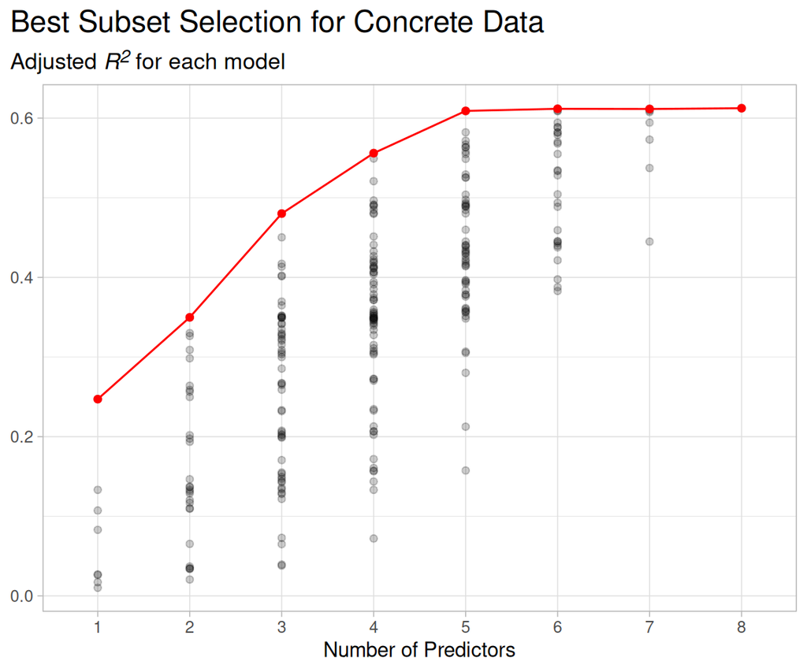

```r
concrete_subset_adjr2 <- as_tibble(summary(regfit_full)$which, rownames = "model") |>
  select(model) |>
  bind_cols(as_tibble_col(summary(regfit_full)$adjr2, column_name = "adjr2")) |>
  mutate(model = as_factor(model))

concete_model_max_adjr2 <- concrete_subset_adjr2 |>
  group_by(model) |>
  summarise(adjr2 = max(adjr2)) |>
  ungroup()

concrete_subset_adjr2 |>
  ggplot() +
  geom_point(aes(x = model, y = adjr2), alpha = 1/5) +
  geom_line(aes(x = model, y = adjr2, group = 1),
            data = concete_model_max_adjr2,
            color = "red") +
   geom_point(aes(x = model, y = adjr2),
            data = concete_model_max_adjr2,
            color = "red") +
  labs(
    title = "Best Subset Selection for Concrete Data",
    subtitle = "Adjusted *R<sup>2</sup>* for each model",
    x = "Number of Predictors",
    y = NULL
  ) +
  theme_light() +
  theme(
   plot.title = ggtext::element_markdown(size = 16),
   plot.title.position = "plot",
   plot.subtitle = ggtext::element_markdown(size = 12)
  )
```

## Best Subset Selection (8/9)

### Focus on best models for each number of predictors

```r
regfit_full_8 <- regsubsets(strength ~ ., data = concrete, nvmax = 8, really.big = FALSE)

summary(regfit_full_8)
```

```
Subset selection object
Call: regsubsets.formula(strength ~ ., data = concrete, nvmax = 8,
    really.big = FALSE)
8 Variables  (and intercept)
                 Forced in Forced out
cement               FALSE      FALSE
slag                 FALSE      FALSE
ash                  FALSE      FALSE
water                FALSE      FALSE
superplasticizer     FALSE      FALSE
coarse_aggregate     FALSE      FALSE
fine_aggregate       FALSE      FALSE
age                  FALSE      FALSE
1 subsets of each size up to 8
Selection Algorithm: exhaustive
         cement slag ash water superplasticizer coarse_aggregate fine_aggregate
1  ( 1 ) "*"    " "  " " " "   " "              " "              " "
2  ( 1 ) "*"    " "  " " " "   "*"              " "              " "
3  ( 1 ) "*"    " "  " " " "   "*"              " "              " "
4  ( 1 ) "*"    "*"  " " "*"   " "              " "              " "
5  ( 1 ) "*"    "*"  "*" "*"   " "              " "              " "
6  ( 1 ) "*"    "*"  "*" "*"   "*"              " "              " "
7  ( 1 ) "*"    "*"  "*" "*"   "*"              "*"              " "
8  ( 1 ) "*"    "*"  "*" "*"   "*"              "*"              "*"
         age
1  ( 1 ) " "
2  ( 1 ) " "
3  ( 1 ) "*"
4  ( 1 ) "*"
5  ( 1 ) "*"
6  ( 1 ) "*"
7  ( 1 ) "*"
8  ( 1 ) "*"
```

## Best Subset Selection (9/9)

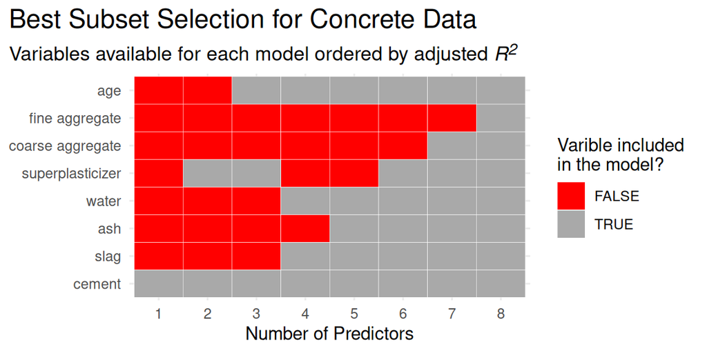

```r
as_tibble(summary(regfit_full_8)$which, rownames = "model") |>
  mutate(
    adjr2 = summary(regfit_full_8)$adjr2,
    model = as_factor(model),
    ) |>
  select(-`(Intercept)`) |>
  pivot_longer(cols = 2:9, , names_to = "variable", values_to = "included") |>
  mutate(variable = str_replace(variable, "_", " ")) |>
  mutate(variable = reorder(as_factor(variable), adjr2)) |>
  ggplot() +
  geom_tile(aes(x = model, y = variable, fill = included), color = "white") +
  labs(
    title = "Best Subset Selection for Concrete Data",
    subtitle = "Variables available for each model ordered by adjusted *R<sup>2</sup>*",
    x = "Number of Predictors",
    y = NULL,
    fill = "Varible included \nin the model?"
  ) +
  scale_fill_manual(values = c("red", "darkgrey")) +
  scale_x_discrete() +
  theme_minimal() +
  theme(
   plot.title = ggtext::element_markdown(size = 16),
   plot.title.position = "plot",
   plot.subtitle = ggtext::element_markdown(size = 12)
  )
```

Subset selection is a useful tool for selecting the best model for a given data set; however, it can be computationally expensive.

If the number of predictors is large, the chance of overfitting the model also increases.

## Stepwise Selection

We can use *Stepwise* methods to evaluate models with a large number of predictors.

### Forward Selection

Forward selection starts with the null model and adds predictors one at a time. The number of models fit is

$$1 + p(p+1)/2$$

For our example of $p = 8$ predictors, this would be $1 + 8(8+1)/2 = 37$ models instead of the $2^8 = 256$ models for best subset selection.

### Backward Selection

Backward selection starts with the full model and removes predictors one at a time. The number of models fit is the same as for forward selection.

## Stepwise Selection Algorithms

### Forward Selection

1. Start with the null model, $M_0$, which contains no predictors.
2. For $k=0,1,\ldots,p-1$:
   1. Consider all $p-k$ models that augment the predictors in $M_k$ with one additional predictor.
   2. Choose the best among these $p-k$ models, and call it $M_{k+1}$. Here best is defined as having the smallest RSS or highest $R^2$.
3. Select a single best model from among $M_0, M_1, \ldots, M_p$ using cross-validated prediction error, $C_p$, BIC, or adjusted $R^2$.

### Backward Selection

1. Start with the full model, $M_p$, which contains all predictors.
2. For $k=p,p-1,\ldots,1$:
   1. Consider all $k$ models that contain all but one of the predictors in $M_k$, for a total of $k-1$ predictors.
   2. Choose the best among these $k$ models, and call it $M_{k-1}$. Here best is defined as having the smallest RSS or highest $R^2$.
3. Select a single best model from among $M_0, M_1, \ldots, M_p$ using cross-validated prediction error, $C_p$, BIC, or adjusted $R^2$.

## Stepwise Selection: Forward Selection

```r
regfit_forward <- regsubsets(strength ~ ., data = concrete, nvmax = 8, method = "forward")

summary(regfit_forward)
```

```
Subset selection object
Call: regsubsets.formula(strength ~ ., data = concrete, nvmax = 8,
    method = "forward")
8 Variables  (and intercept)
                 Forced in Forced out
cement               FALSE      FALSE
slag                 FALSE      FALSE
ash                  FALSE      FALSE
water                FALSE      FALSE
superplasticizer     FALSE      FALSE
coarse_aggregate     FALSE      FALSE
fine_aggregate       FALSE      FALSE
age                  FALSE      FALSE
1 subsets of each size up to 8
Selection Algorithm: forward
         cement slag ash water superplasticizer coarse_aggregate fine_aggregate
1  ( 1 ) "*"    " "  " " " "   " "              " "              " "
2  ( 1 ) "*"    " "  " " " "   "*"              " "              " "
3  ( 1 ) "*"    " "  " " " "   "*"              " "              " "
4  ( 1 ) "*"    "*"  " " " "   "*"              " "              " "
5  ( 1 ) "*"    "*"  " " "*"   "*"              " "              " "
6  ( 1 ) "*"    "*"  "*" "*"   "*"              " "              " "
7  ( 1 ) "*"    "*"  "*" "*"   "*"              "*"              " "
8  ( 1 ) "*"    "*"  "*" "*"   "*"              "*"              "*"
         age
1  ( 1 ) " "
2  ( 1 ) " "
3  ( 1 ) "*"
4  ( 1 ) "*"
5  ( 1 ) "*"
6  ( 1 ) "*"
7  ( 1 ) "*"
8  ( 1 ) "*"
```

## Stepwise Selection: Backward Selection

```r
regfit_backward <- regsubsets(strength ~ ., data = concrete, nvmax = 8, method = "backward")

summary(regfit_backward)
```

```
Subset selection object
Call: regsubsets.formula(strength ~ ., data = concrete, nvmax = 8,
    method = "backward")
8 Variables  (and intercept)
                 Forced in Forced out
cement               FALSE      FALSE
slag                 FALSE      FALSE
ash                  FALSE      FALSE
water                FALSE      FALSE
superplasticizer     FALSE      FALSE
coarse_aggregate     FALSE      FALSE
fine_aggregate       FALSE      FALSE
age                  FALSE      FALSE
1 subsets of each size up to 8
Selection Algorithm: backward
         cement slag ash water superplasticizer coarse_aggregate fine_aggregate
1  ( 1 ) "*"    " "  " " " "   " "              " "              " "
2  ( 1 ) "*"    " "  " " " "   " "              " "              " "
3  ( 1 ) "*"    " "  " " "*"   " "              " "              " "
4  ( 1 ) "*"    "*"  " " "*"   " "              " "              " "
5  ( 1 ) "*"    "*"  "*" "*"   " "              " "              " "
6  ( 1 ) "*"    "*"  "*" "*"   "*"              " "              " "
7  ( 1 ) "*"    "*"  "*" "*"   "*"              "*"              " "
8  ( 1 ) "*"    "*"  "*" "*"   "*"              "*"              "*"
         age
1  ( 1 ) " "
2  ( 1 ) "*"
3  ( 1 ) "*"
4  ( 1 ) "*"
5  ( 1 ) "*"
6  ( 1 ) "*"
7  ( 1 ) "*"
8  ( 1 ) "*"
```

## Comparing Models for Subset Selection Methods

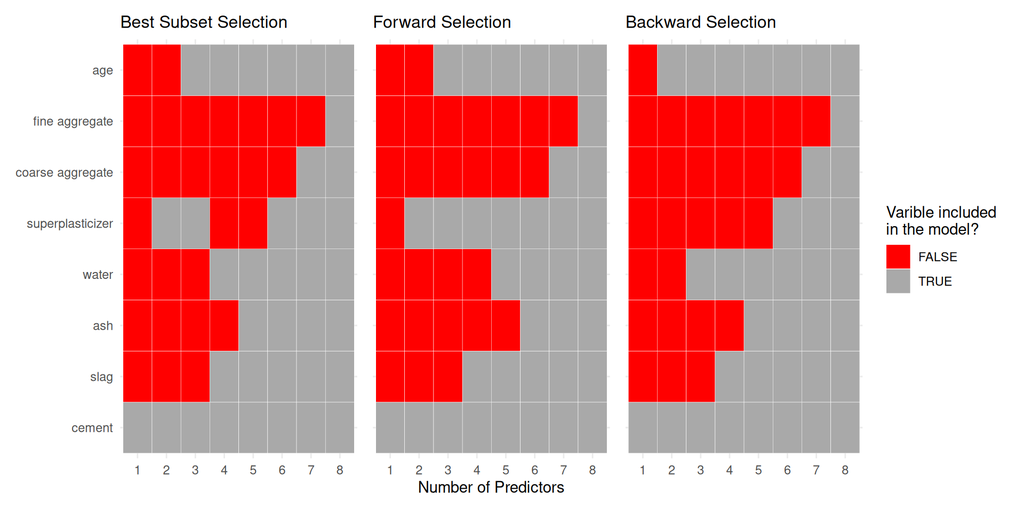

## Choosing the Optimal Model

**Important**

The model containing all of the predictors will always have the smallest $RSS$ and the largest $R^2$

Recall, we want to choose a model based on its ability to predict new data.

In the above examples, we didn’t create a test set to evaluate the models, we simply used the entire dataset.

Unfortunately, the `regsubsets()` function does not have a built-in method for evaluating models on a test set.

## Metrics for Model Selection (1/2)

### RSS: Residual Sum of Squares

$$RSS = \sum_{i=1}^{n} (y_i - \hat{y}_i)^2$$

### $R^2$: Coefficient of Determination

$$R^2 = 1 - \frac{RSS}{TSS}$$

$TSS = \sum_{i=1}^{n} (y_i - \bar{y})^2$ is the Total Sum of Squares.

### MSE: Mean Squared Error

$$MSE = \frac{1}{n} \sum_{i=1}^{n} (y_i - \hat{y}_i)^2 = \frac{RSS}{n}$$

## Metrics for Model Selection (2/2)

### Adjusted $R^2$:

$$\textrm{Adjusted }R^2 = 1 - \frac{RSS/(n-d-1)}{TSS/(n-1)}$$

### Mallows’ $C_p$:

$$C_p = \frac{1}{n} (RSS + 2d\hat{\sigma}^2)$$

### Akaike Information Criterion (AIC):

$$\textrm{AIC} = n\log\left(\frac{\text{RSS}}{n}\right) + 2(d+2),$$

### Bayesian Information Criterion (BIC):

$$BIC = \frac{1}{n} (RSS + \log(n)d\hat{\sigma}^2)$$

where $d$ is the number of predictors in the model and $\hat{\sigma}^2$ is an estimate of the variance of the error term.

## Working with Combinations

Walk through the following code to examing how we can work with combinations of predictors.

```r
# Initialize an empty list to store model information
model_list <- list()

total_combinations <- 0

for (i in 1:8) {
  concrete_predictors <- combn(concrete_column_names[1:8], i)
  num_combinations <- ncol(concrete_predictors)

  cat(sprintf("\nNumber of predictors: %d\n", i))
  cat(sprintf("Number of combinations: %d\n", num_combinations))

  total_combinations <- total_combinations + num_combinations

  for (j in 1:num_combinations) {
    formula <- reformulate(concrete_predictors[,j], response = "strength")
    model_combination <- lm(formula, data = concrete)

    # Add model information to the list
    model_list[[length(model_list) + 1]] <- list(
      num_predictors = i,
      combination = paste(concrete_predictors[,j], collapse = ", "),
      formula = paste(deparse(formula), collapse = " "),  # Ensure single string
      model = model_combination
    )
  }
}
```

```
Number of predictors: 1
Number of combinations: 8

Number of predictors: 2
Number of combinations: 28

Number of predictors: 3
Number of combinations: 56

Number of predictors: 4
Number of combinations: 70

Number of predictors: 5
Number of combinations: 56

Number of predictors: 6
Number of combinations: 28

Number of predictors: 7
Number of combinations: 8

Number of predictors: 8
Number of combinations: 1
```

```r
# Convert the list to a tibble
model_results <- tibble::tibble(
  num_predictors = map_int(model_list, "num_predictors"),
  combination = map_chr(model_list, "combination"),
  formula = map_chr(model_list, "formula"),
  model = map(model_list, "model")
)

cat(sprintf("\nTotal number of combinations: %d\n", total_combinations))
```

```
Total number of combinations: 255
```

```r
cat(sprintf("Number of rows in model_results: %d\n", nrow(model_results)))
```

```
Number of rows in model_results: 255
```

```r
# Display the resulting tibble
model_results
```

| num_predictors | combination | formula | model |
| --- | --- | --- | --- |
| 1 | cement | strength ~ cement |  |
| 1 | slag | strength ~ slag |  |
| 1 | ash | strength ~ ash |  |
| 1 | water | strength ~ water |  |
| 1 | superplasticizer | strength ~ superplasticizer |  |
| 1 | coarse_aggregate | strength ~ coarse_aggregate |  |
| 1 | fine_aggregate | strength ~ fine_aggregate |  |
| 1 | age | strength ~ age |  |
| 2 | cement, slag | strength ~ cement + slag |  |
| 2 | cement, ash | strength ~ cement + ash |  |

[output cut: 245 more lines]

## Custom Function to Split Data and Compare Models

For many cases, you’ll be able to use package functions to perform model selection.

```r
# Created with the help of Calude.ai

compare_models <- function(data, response_var, predictor_vars, proportion = 0.8, seed = NULL) {
  # Set seed if provided
  if (!is.null(seed)) set.seed(seed)

  # Capture the predictor variables
  pred_vars <- enquo(predictor_vars)

  # Select the specified columns
  selected_data <- data |>
    select(!!response_var, !!pred_vars)

  # Get column names
  all_column_names <- colnames(selected_data)
  response_name <- as.character(response_var)
  predictor_names <- setdiff(all_column_names, response_name)

  # Create train/test split
  n <- nrow(selected_data)
  train_indices <- sample(1:n, size = round(proportion * n))
  train_data <- selected_data[train_indices, ]
  test_data <- selected_data[-train_indices, ]

  # Initialize an empty list to store model information
  model_list <- list()
  total_combinations <- 0

  for (i in 1:length(predictor_names)) {
    predictor_combinations <- combn(predictor_names, i)
    num_combinations <- ncol(predictor_combinations)

    total_combinations <- total_combinations + num_combinations

    for (j in 1:num_combinations) {
      formula <- reformulate(predictor_combinations[,j], response = response_name)
      model_combination <- lm(formula, data = train_data)

      # Make predictions on test data
      predictions <- predict(model_combination, newdata = test_data)

      # Calculate RMSE and R-squared on test data
      rmse <- sqrt(mean((test_data[[response_name]] - predictions)^2))
      rsq <- cor(test_data[[response_name]], predictions)^2

      # Add model information to the list
      model_list[[length(model_list) + 1]] <- list(
        num_predictors = i,
        combination = paste(predictor_combinations[,j], collapse = ", "),
        formula = paste(deparse(formula), collapse = " "),
        model = model_combination,
        test_rmse = rmse,
        test_rsq = rsq
      )
    }
  }

  # Convert the list to a tibble
  model_results <- tibble::tibble(
    num_predictors = map_int(model_list, "num_predictors"),
    combination = map_chr(model_list, "combination"),
    formula = map_chr(model_list, "formula"),
    model = map(model_list, "model"),
    test_rmse = map_dbl(model_list, "test_rmse"),
    test_rsq = map_dbl(model_list, "test_rsq")
  )

  cat(sprintf("\nTotal number of models: %d\n", nrow(model_results)))

  return(model_results)
}

# Example usage:
result <- compare_models(concrete, "strength", concrete_column_names, proportion = 0.8, seed = 42)
```

```
Total number of models: 255
```

```r
# View results:
# result |>  arrange(test_rmse) |>  head(10)  # Top 10 models by RMSE
result |>  arrange(desc(test_rsq)) |>  head(10)  # Top 10 models by R-squared
```

| num_predictors | combination | formula | model | test_rmse | test_rsq |
| --- | --- | --- | --- | --- | --- |
| 7 | cement, slag, ash, water, superplasticizer, fine_aggregate, age | strength ~ cement + slag + ash + water + superplasticizer + fine_aggregate + age |  | 10.32837 | 0.5926672 |
| 6 | cement, slag, ash, water, superplasticizer, age | strength ~ cement + slag + ash + water + superplasticizer + age |  | 10.33075 | 0.5924706 |
| 7 | cement, slag, ash, water, superplasticizer, coarse_aggregate, age | strength ~ cement + slag + ash + water + superplasticizer + coarse_aggregate + age |  | 10.35889 | 0.5902036 |
| 6 | cement, slag, ash, water, fine_aggregate, age | strength ~ cement + slag + ash + water + fine_aggregate + age |  | 10.38609 | 0.5880555 |
| 5 | cement, slag, ash, water, age | strength ~ cement + slag + ash + water + age |  | 10.40006 | 0.5869700 |
| 6 | cement, slag, ash, water, coarse_aggregate, age | strength ~ cement + slag + ash + water + coarse_aggregate + age |  | 10.40417 | 0.5866490 |
| 8 | cement, slag, ash, water, superplasticizer, coarse_aggregate, fine_aggregate, age | strength ~ cement + slag + ash + water + superplasticizer + coarse_aggregate + fine_aggregate + age |  | 10.41787 | 0.5855362 |
| 7 | cement, slag, water, superplasticizer, coarse_aggregate, fine_aggregate, age | strength ~ cement + slag + water + superplasticizer + coarse_aggregate + fine_aggregate + age |  | 10.46004 | 0.5834251 |
| 7 | cement, slag, ash, water, coarse_aggregate, fine_aggregate, age | strength ~ cement + slag + ash + water + coarse_aggregate + fine_aggregate + age |  | 10.45837 | 0.5824165 |
| 6 | cement, slag, water, coarse_aggregate, fine_aggregate, age | strength ~ cement + slag + water + coarse_aggregate + fine_aggregate + age |  | 10.51698 | 0.5784576 |

## Test Model Results

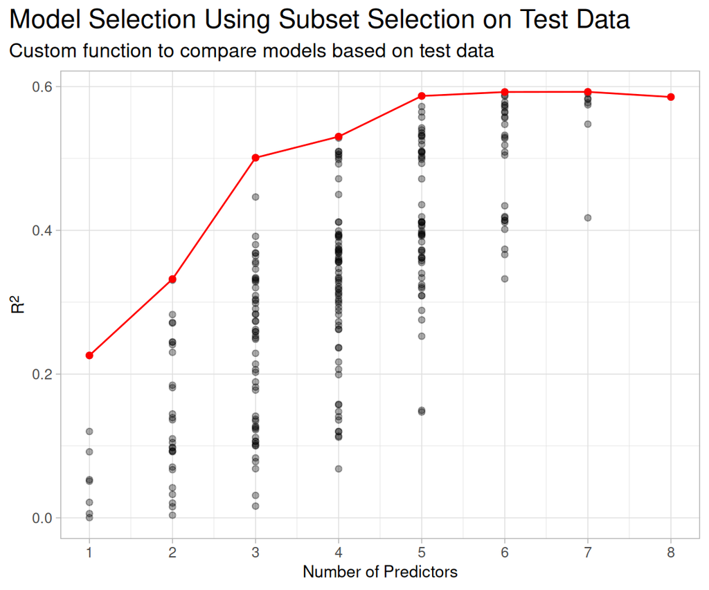

```r
max_results <- result |>
  group_by(num_predictors) |>
  filter(test_rsq == max(test_rsq)) |>
  ungroup()

result |>
  ggplot() +
  geom_point(aes(x = num_predictors, y = test_rsq), alpha = 1/3) +
  geom_line(aes(x = num_predictors, y = test_rsq), data = max_results, color = "red") +
  geom_point(aes(x = num_predictors, y = test_rsq), data = max_results, color = "red") +
  labs(
    title = "Model Selection Using Subset Selection on Test Data",
    subtitle = "Custom function to compare models based on test data",
    x = "Number of Predictors",
    y = "R<sup>2</sup>"
  ) +
  scale_x_continuous(breaks = 1:8) +
  theme_light() +
  theme(
   plot.title = ggtext::element_markdown(size = 16),
   plot.title.position = "plot",
   plot.subtitle = ggtext::element_markdown(size = 12),
   axis.title = ggtext::element_markdown(size = 10)
  )
```

## Assignment: Subset Selection Methods

### ISLR Lab: 6.5.1 Subset Selection Methods

## Shrinkage Methods

### Ridge Regression

### Lasso

### Elastic Net

### Selecting the Tuning Parameter

## Ridge Regression

Recall that linear regression minimizes RSS to find the best-fitting line.

$$RSS = \sum_{i=1}^{n} (y_i - \hat{y}_i)^2 = \sum_{i=1}^{n} \left (y_i - \beta_0 - \sum_{j=1}^{p} \beta_j x_{ij} \right )^2$$

Ridge regression adds a penalty term to the RSS to shrink the coefficients towards zero.

$$\sum_{i=1}^{n} \left (y_i - \beta_0 - \sum_{j=1}^{p} \beta_j x_{ij} \right )^2 + \lambda \sum_{j=1}^{p} \beta_j^2$$

$\lambda$ controls the amount of shrinkage.

$\lambda \ge 0$ is a *tuning parameter* that controls the amount of shrinkage and is determined using cross-validation.

**Note**

We will use the `glmnet` package to perform ridge regression.

## Ridge Regression Penalty Term

The penalty term is often referred to as l2 regularization and has a shorthand notation of

$$|| \beta ||_2^2 = \sum_{j=1}^{p} \beta_j^2$$

## Scaling the Data

### Standardizing the Predictors (ISLR, 239)

> The ridge regression coeﬀicient estimates can change substantially when multiplying a given predictor by a constant.  
> $X_j \hat{\beta}_{j,\lambda}^R$ will depend not only on the value of $\lambda$, but also on the scaling of the $j$th predictor. . . the value of $X_j \hat{\beta}_{j,\lambda}^R$ may even depend on the scaling of the other predictors! Therefore, it is best to apply ridge regression after standardizing the predictors, using the formula

$$\tilde{x}_{ij} = \frac{x_{ij}}{\sqrt{\frac{1}{n} \sum_{i=1}^{n} (x_{ij} - \bar{x}_j)^2}}$$

### Standardization the Predictors (more common method)

Alternatively, we can use the `scale()` function in R to center and scale the predictors.  
This is often referred to as *z-score* scaling.

$$\tilde{x}_{ij} = \frac{x_{ij} - \bar{x}_j}{\sqrt{\frac{1}{n} \sum_{i=1}^{n} (x_{ij} - \bar{x}_j)^2}}$$

## Ridge Regression Example (1/2)

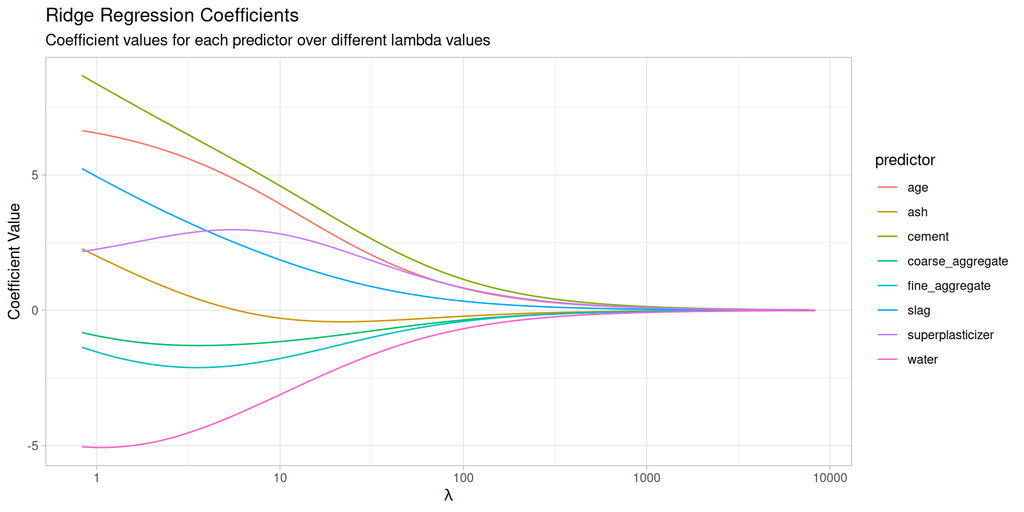

```r
concrete_ridge <- glmnet(x = scale(as.matrix(concrete[, 1:8])), y = concrete$strength, alpha = 0, standardize = FALSE)

# names(concrete_ridge)
# concrete_ridge$lambda

as_tibble(as.matrix(concrete_ridge$beta), rownames = "predictor") |>
  pivot_longer(cols = 2:101, names_to = "lambda", values_to = "beta_values") |>
  mutate(lambda_values = rep(concrete_ridge$lambda, times = 8)) |>
  ggplot() +
  geom_line(aes(x = lambda_values, y = beta_values, color = predictor)) +
  labs(
    title = "Ridge Regression Coefficients",
    subtitle = "Coefficient values for each predictor over different lambda values",
    x = TeX(r'($lambda$)'),
    y = "Coefficient Value"
  ) +
  scale_x_log10() +
  theme_light()
```

## Ridge Regression Example (2/2)

### With Cross-Validation

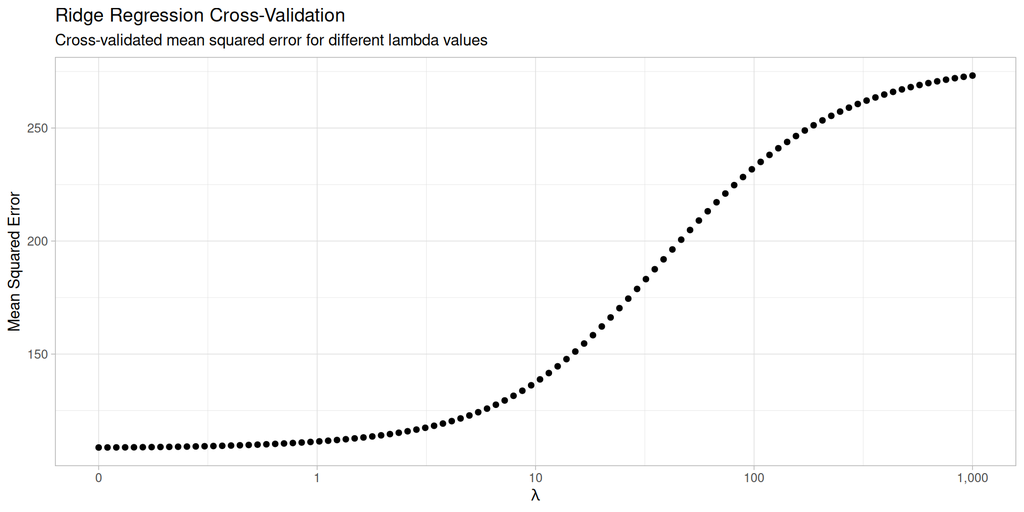

```r
lambda_values <- 10^seq(3, -1, length = 100)

concrete_ridge_cv <- cv.glmnet(x = scale(as.matrix(concrete[, 1:8])), y = concrete$strength, alpha = 0, standardize = FALSE, nfolds = 10, lambda = lambda_values)

ggplot() +
  geom_point(aes(x = concrete_ridge_cv$lambda, y = concrete_ridge_cv$cvm)) +
  labs(
    title = "Ridge Regression Cross-Validation",
    subtitle = "Cross-validated mean squared error for different lambda values",
    x = TeX(r'($\lambda$)'),
    y = "Mean Squared Error"
  ) +
  scale_x_log10(label = scales::label_comma(accuracy = 1)) +
  theme_light()
```

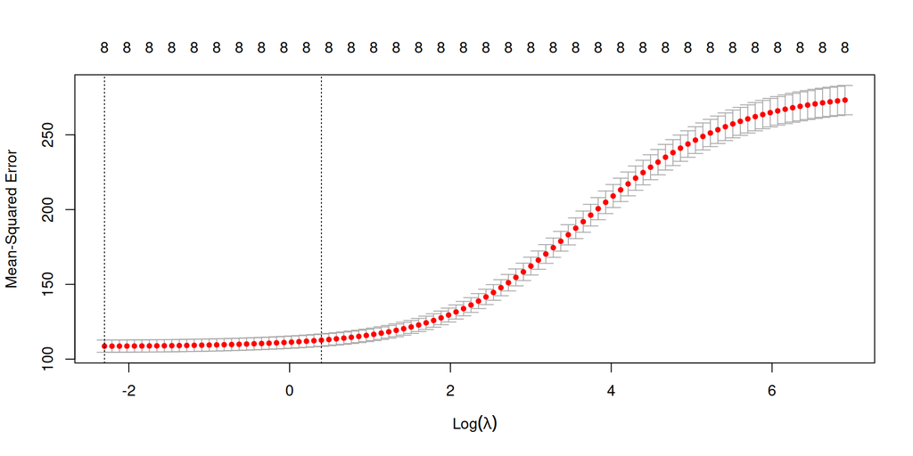

```r
plot(concrete_ridge_cv)
```

## The Lasso

### Lasso stands for Least Absolute Shrinkage and Selection Operator.

### The lasso penalty term is l1 regularization.

$$\sum_{i=1}^{n} \left (y_i - \beta_0 - \sum_{j=1}^{p} \beta_j x_{ij} \right )^2 + \lambda \sum_{j=1}^{p} | \beta_j |$$

Similar to Ridge regression, $\lambda \ge 0$ is a *tuning parameter* that controls the amount of shrinkage and is determined using cross-validation.

Unlike Ridge regression, the lasso can set coefficients to zero, effectively performing variable selection.

The data should be standardized before using the lasso.

## Lasso Example (1/2)

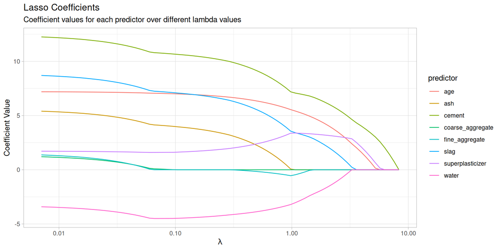

```r
concrete_lasso <- glmnet(x = scale(as.matrix(concrete[, 1:8])), y = concrete$strength, alpha = 1, standardize = FALSE)

as_tibble(as.matrix(concrete_lasso$beta), rownames = "predictor") |>
  pivot_longer(cols = 2:78, names_to = "lambda", values_to = "beta_values") |>
  mutate(lambda_values = rep(concrete_lasso$lambda, times = 8)) |>
  ggplot() +
  geom_line(aes(x = lambda_values, y = beta_values, color = predictor)) +
  labs(
    title = "Lasso Coefficients",
    subtitle = "Coefficient values for each predictor over different lambda values",
    x = TeX(r'($\lambda$)'),
    y = "Coefficient Value"
  ) +
  scale_x_log10() +
  theme_light()
```

## Lasso Example (2/2)

### With Cross-Validation

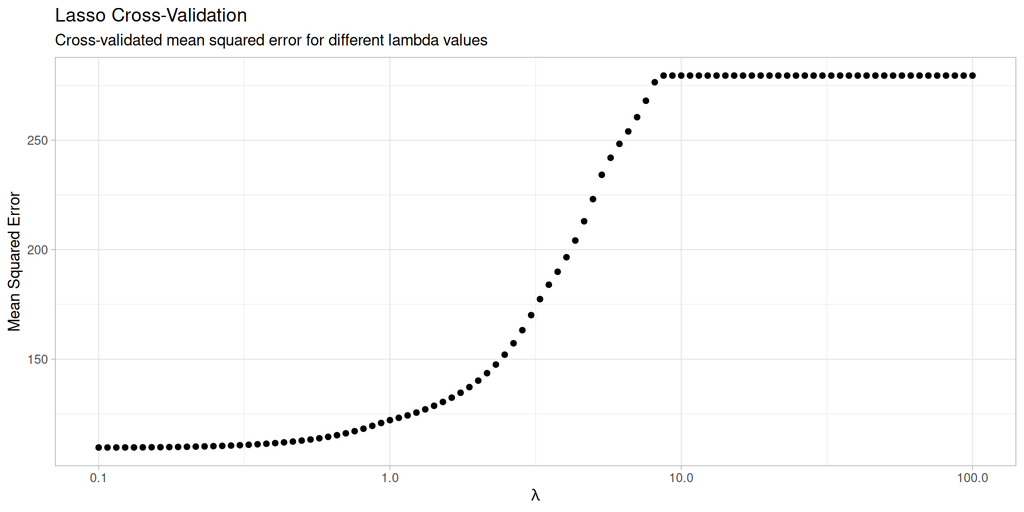

```r
lambda_values <- 10^seq(2, -1, length = 100)

concrete_lasso_cv <- cv.glmnet(x = scale(as.matrix(concrete[, 1:8])), y = concrete$strength, alpha = 1, standardize = FALSE, nfolds = 10, lambda = lambda_values)

ggplot() +
  geom_point(aes(x = concrete_lasso_cv$lambda, y = concrete_lasso_cv$cvm)) +
  labs(
    title = "Lasso Cross-Validation",
    subtitle = "Cross-validated mean squared error for different lambda values",
    x = TeX(r'($\lambda$)'),
    y = "Mean Squared Error"
  ) +
  scale_x_log10() +
  theme_light()
```

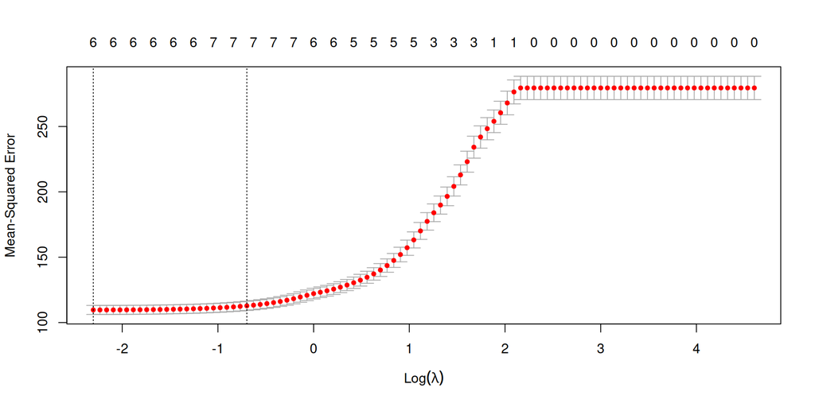

```r
plot(concrete_lasso_cv)
```

## Elastic Net

### Elastic Net is a combination of Ridge and Lasso regression.

$$\sum_{i=1}^{n} \left (y_i - \beta_0 - \sum_{j=1}^{p} \beta_j x_{ij} \right )^2 + \lambda \left ( \alpha \sum_{j=1}^{p} | \beta_j | + (1 - \alpha) \sum_{j=1}^{p} \beta_j^2 \right )$$

where $\alpha$ controls the balance between Ridge and Lasso regression.

$\alpha = 1$ is Lasso regression and is the default in `glmnet`. $\alpha = 0$ is Ridge regression.

## Assignment: Ridge Regression and the Lasso

### ISLR Lab: 6.5.2 Ridge Regression and the Lasso

## Readings (1/2)

### Dimension Reduction Methods

### Principal Components Regression

### Partial Least Squares

### Principal Components Regression

### Partial Least Squares

## Readings (2/2)

### Considerations in High Dimensions

### High-Dimensional Data

### What Goes Wrong in High Dimensions?

### Regression in High Dimensions

### Interpreting Results in High Dimenions

# Moving Beyond Linearity

## Polynomial Regression (1/)

We can extend linear regression to include polynomial terms where the coefficients are still linear, but the predictors are polynomial terms of the original predictors.

$$y_i = \beta_0 + \beta_1 x_i + \beta_2 x_i^2 + \ldots + \beta_d x_i^d + \epsilon_i$$

In most cases, the value of $d$ is small, often 2 or 3 as higher values can lead to over fitting.

## Polynomial Regression (2/)

### Example 1: Quadratic Regression on Loadcell data

```r
loadcell <- read_table("datasets/LOADCELL.DAT", skip = 25, col_names = c("Load Level", "Response"))
loadcell
```

| Load Level | Response |
| --- | --- |
| 2 | 0.20024 |
| 2 | 0.20016 |
| 2 | 0.20024 |
| 4 | 0.40056 |
| 4 | 0.40045 |
| 4 | 0.40054 |
| 6 | 0.60087 |
| 6 | 0.60075 |
| 6 | 0.60086 |
| 8 | 0.80130 |

[output cut: 23 more lines]

## Polynomial Regression (3/)

### Example 1: EDA of Loadcell data

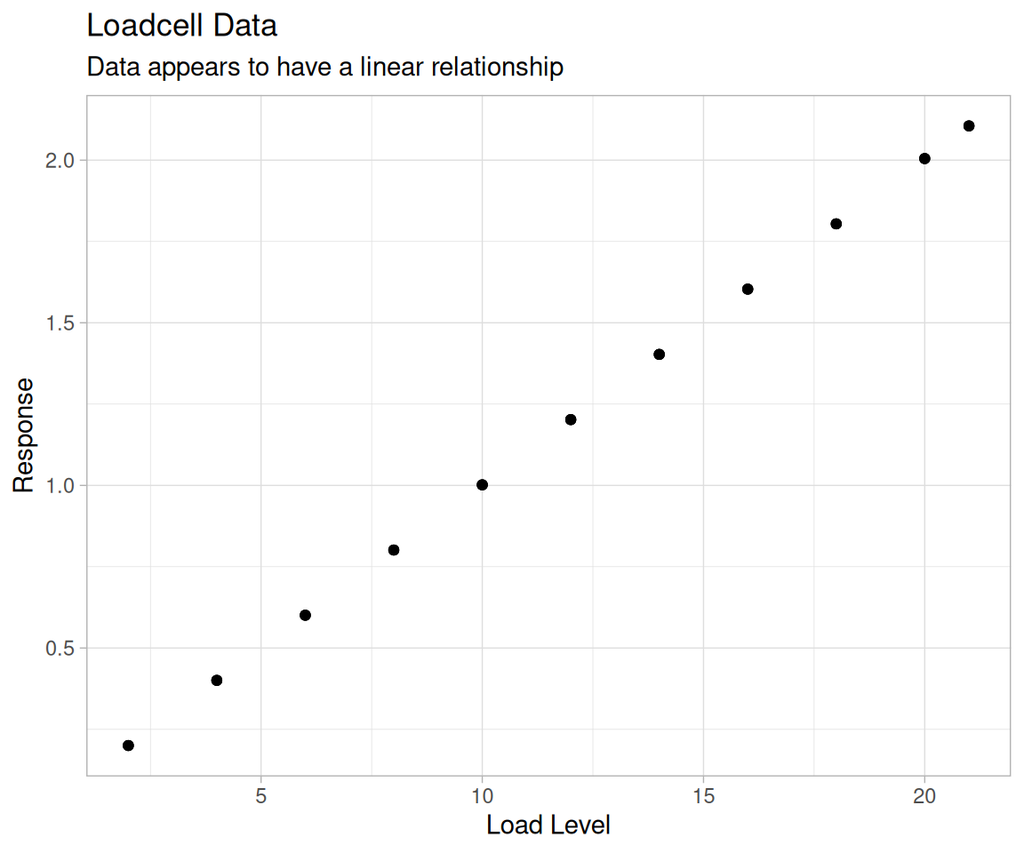

```r
loadcell |>
  ggplot() +
  geom_point(aes(x = `Load Level`, y = Response)) +
  labs(
    title = "Loadcell Data",
    subtitle = "Data appears to have a linear relationship",
    x = "Load Level",
    y = "Response"
  ) +
  theme_light()
```

## Polynomial Regression (4/)

### Example 1: Quadratic Regression on Loadcell data

```r
loadcell_lm <- lm(Response ~ `Load Level`, data = loadcell)
summary(loadcell_lm)
```

```
Call:
lm(formula = Response ~ `Load Level`, data = loadcell)

Residuals:
       Min         1Q     Median         3Q        Max
-3.181e-04 -2.075e-04 -2.862e-05  1.983e-04  4.208e-04

Coefficients:
               Estimate Std. Error   t value Pr(>|t|)
(Intercept)  -7.156e-04  9.025e-05    -7.929 5.97e-09 ***
`Load Level`  1.003e-01  6.725e-06 14909.755  < 2e-16 ***
---
Signif. codes:  0 '***' 0.001 '**' 0.01 '*' 0.05 '.' 0.1 ' ' 1

Residual standard error: 0.000239 on 31 degrees of freedom
Multiple R-squared:      1, Adjusted R-squared:      1
F-statistic: 2.223e+08 on 1 and 31 DF,  p-value: < 2.2e-16
```

**Note:** R-squared is 1!

## Polynomial Regression (5/)

### Example 1: Inspect the resiuals

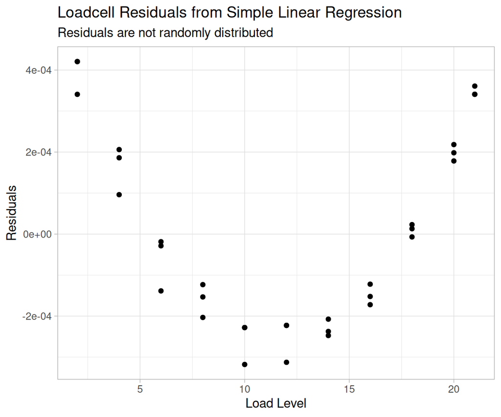

```r
loadcell_resid <- augment(loadcell_lm)
loadcell_resid |>
  ggplot() +
  geom_point(aes(x = `Load Level`, y = .resid)) +
  labs(
    title = "Loadcell Residuals from Simple Linear Regression",
    subtitle = "Residuals are not randomly distributed",
    x = "Load Level",
    y = "Residuals"
  ) +
  theme_light()
```

## Polynomial Regression (6/)

### Example 1: Quadratic Regression on Loadcell data

```r
loadcell_lm_quad <- lm(Response ~ poly(`Load Level`, 2), data = loadcell)
summary(loadcell_lm_quad)
```

```
Call:
lm(formula = Response ~ poly(`Load Level`, 2), data = loadcell)

Residuals:
       Min         1Q     Median         3Q        Max
-9.966e-05 -1.466e-05  5.944e-06  2.515e-05  5.595e-05

Coefficients:
                        Estimate Std. Error   t value Pr(>|t|)
(Intercept)            1.193e+00  6.552e-06 182130.14   <2e-16 ***
poly(`Load Level`, 2)1 3.563e+00  3.764e-05  94658.88   <2e-16 ***
poly(`Load Level`, 2)2 1.314e-03  3.764e-05     34.92   <2e-16 ***
---
Signif. codes:  0 '***' 0.001 '**' 0.01 '*' 0.05 '.' 0.1 ' ' 1

Residual standard error: 3.764e-05 on 30 degrees of freedom
Multiple R-squared:      1, Adjusted R-squared:      1
F-statistic: 4.48e+09 on 2 and 30 DF,  p-value: < 2.2e-16
```

## Polynomial Regression (7/)

### Example 1: Inspect the resiuals of the quadrtic model

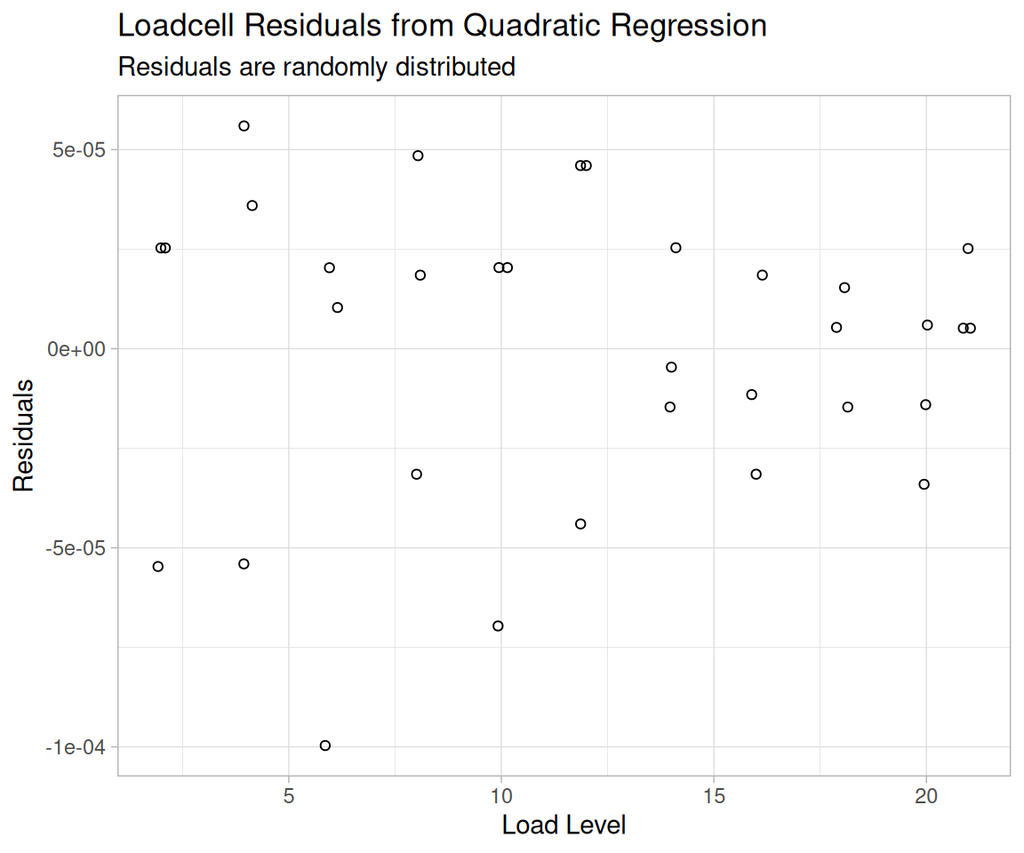

```r
set.seed(42) # added so jitter will not change between renders
loadcell_resid_quad <- augment(loadcell_lm_quad)
loadcell_resid_quad |>
  ggplot() +
  geom_point(aes(x = loadcell$`Load Level`, y = .resid),
             position = position_jitter(width = 0.15),
             shape = 1) +
  labs(
    title = "Loadcell Residuals from Quadratic Regression",
    subtitle = "Residuals are randomly distributed",
    x = "Load Level",
    y = "Residuals"
  ) +
  theme_light()
```

## Polynomial Regression (8/)

### Example 1: Alternative method to construc the polynomial model

```r
loadcell_lm_quad2 <- lm(Response ~ `Load Level` + I(`Load Level`^2), data = loadcell)
summary(loadcell_lm_quad2)
```

```
Call:
lm(formula = Response ~ `Load Level` + I(`Load Level`^2), data = loadcell)

Residuals:
       Min         1Q     Median         3Q        Max
-9.966e-05 -1.466e-05  5.944e-06  2.515e-05  5.595e-05

Coefficients:
                    Estimate Std. Error   t value Pr(>|t|)
(Intercept)       -1.840e-05  2.451e-05    -0.751    0.459
`Load Level`       1.001e-01  4.839e-06 20687.891   <2e-16 ***
I(`Load Level`^2)  7.032e-06  2.014e-07    34.922   <2e-16 ***
---
Signif. codes:  0 '***' 0.001 '**' 0.01 '*' 0.05 '.' 0.1 ' ' 1

Residual standard error: 3.764e-05 on 30 degrees of freedom
Multiple R-squared:      1, Adjusted R-squared:      1
F-statistic: 4.48e+09 on 2 and 30 DF,  p-value: < 2.2e-16
```

## Assignment: Polynomial Regression

### ISLR Lab: 7.8.1 Polynomial Regression

# End of Module 9